# Elecciones locales en Madrid - 2015

Daniel Almazán

**[English version](https://danielalmazan.com/elections/elections_locals_2015_madrid.html)**

[volver a elections](https://danielalmazan.com/elections/)

### Sobre el proyecto

Este proyecto estudia los resultados de las elecciones locales de 2015 en Madrid, España. Se centra en los porcentajes de voto de los cuatro principales partidos (PP, Ahora Madrid, PSOE y Ciudadanos) y la potencial conexión con la participación y los niveles medios de renta por hogar. El análisis se ha realizado con el mayor nivel de detalle posible, en este caso la sección censal, de las que hay más de 2.000 en Madrid.

### Voto a partidos y distribución izquierda-derecha

**[Este mapa](https://danielalmazan.com/elections/madrid_elections_2015_win.html)** muestra los resultados de las elecciones locales en Madrid, con el partido más votado en cada sección y el porcentaje de voto de 8 partidos diferentes. El reparto de voto a fuerzas de izquierda y derecha también puede verse (*echa un vistazo, ¡está chulo!*).

### Resultados de los cuatro grandes partidos

El mapa situado debajo muestra los porcentajes de voto obtenidos por cada uno de los cuatro partidos principales en las elecciones locales de 2015 en Madrid. La distribución geográfica de los resultados de PP, Ahora Madrid, PSOE y Ciudadanos es diferente y puede ser explorada en detalle en el mapa.

[interactive chart not shown]

### Distribución de participación y partido más votado en cada sección censal

El siguiente mapa muesra los niveles de participación/abstención de cada sección censal en Madrid, así como también el partido que obtuvo el mayor número de votos en esas secciones.

[interactive chart not shown]

### Resultados de cada partido en relación a la participación y la renta media por hogar

El siguiente gráfico muestra la relación entre la participación y el porcentaje de voto de los cuatro grandes partidos en cada sección censal de Madrid, Como puede observarse, hay diferentes patrones para partidos de izquierda y derecha. Mientras Ahora Madrid y (especialmente) PSOE obtienen mejores resultados in aquellas secciones con participaciones por debajo de la media (68,9%), los partidos de derecha (PP y Ciudadanos) tienden a obtener mejores resultados en las secciones con participación más alta.

Este patrón es especialmente claro en los casos de PSOE y PP, mientras que el voto a Ahora Madrid es bastante constante para secciones con participaciones inferiores al 65%, bajando a partir de ahí.

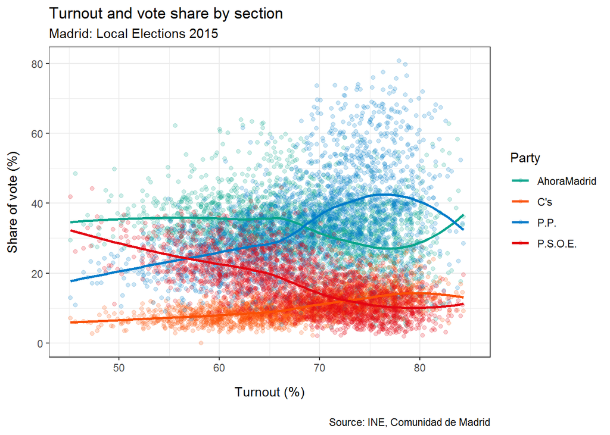

Aunque no hay datos disponibles de renta media por hogar a nivel de secciones censales, datos de Urban Audit aportan información para los llamados *Sub-City Districts* (distritos sub-municipales). Estas áreas están formadas por agregación de secciones censales y tienen tamaños similares a los barrios de Madrid. Para este proyecto, a cada sección censal se le ha asignado la renta media por hogar correspondiente al *Sub-City District* al que pertenece.

El gráfico siguiente muestra la relación entre renta media anual por hogar y el porcentaje de voto de los principales partidos en las elecciones. Está claro que los partidos de izquierda obtienen mejores resultados en aquellas áreas de menor renta y su apoyo disminuye en áreas más pudientes. Por otro lado, los partidos de derecha, y especialmente el PP, obtienen peores resultados en áreas más pobres y su apoyo se incrementa sustancialmente en zonas más ricas.

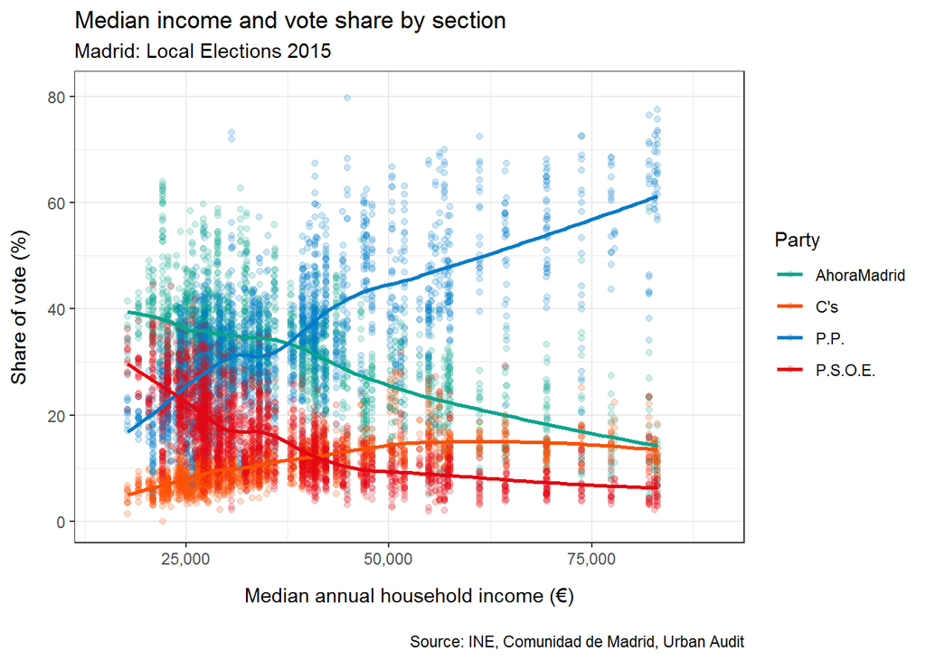

### Participación y renta

Después de haber observado que existe un nivel razonable de correlación entre, por un lado, porcentaje de voto y, por otro lado, participación y renta media, con los partidos de derecha teniendo una correlación positiva entre esas variables y los de izquierda experimentando la situación opuesta, podría ser interesante observar la relación entre la participación y la renta media por hogar.

El gráfico siguiente muestra cada sección censal en Madrid, con la participación en las elecciones locales y la renta media anual por hogar del *Sub-City District* al que pertenece cada sección. Los puntos están coloreados en función del partido más votado en cada sección.

Puede verse que la correlación es más débil aquí, aunque está claro que las áreas con altos ingresos presentan niveles de participación por encima de la media. También es claro que las secciones con baja participación se encuentran generalmente en áreas menos favorecidas. Sin embargo, la correlación no funciona en ambos sentidos, ya que existe una gran dispersión en términos de participación en áreas con bajas rentas.

Otra conclusión que puede extraerse del gráfico es la predominancia del PP en las áreas más ricas, con Ahora Madrid ganando la mayoría de las secciones de menor renta.

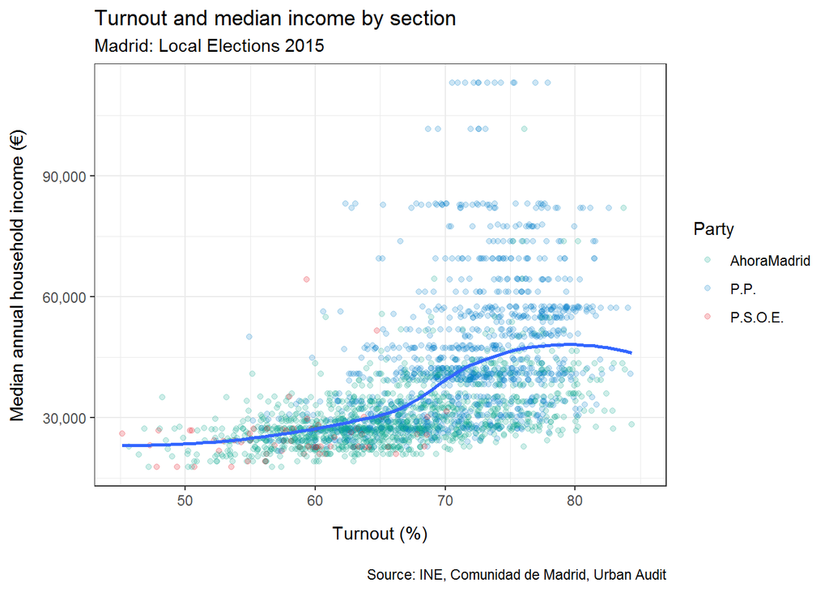

[volver a elections](https://danielalmazan.com/elections/)